# JSE Presentation

Susannah Hogue

2016-03-01

Where to go: https://github.com/hoguesj/sharingIScaring

# Introduction to claims and data

This activity presents three related datasets on battery life that are easy for students to understand. Research had previously been done on these datasets, and it had been concluded that Ultracell AA Alkaline (ALDI battery brand brand) batteries outperformed the Energizer Max AA Alkaline batteries.

The following tests were conducted each using 9 batteries from each brand:

1. Batteries were loaded with a camera flash, using 1000 m A loaded for 10 s/min for one hour per day. The number of “pulses” to reach pre-defined voltage levels was recorded.
2. Batteries were loaded using a 250 m A electronic game for one hour per day. The time taken to reach pre-defined voltage levels was recorded.
3. Batteries were loaded with a digital camera drawing 1500 m W / 650 m W, for 2s every 28 s, for 5 min/h for 24 hours/day. The number of “pulses” to reach pre-defined voltage levels was recorded.

This activity focuses on the data from Test 2. Test 2 is the only test in which ALDI did not claim their batteries were superior to Energizer.

- *Do you have any personal experiences that make you think one brand would be better than the other?*

# Getting into some statistics

- *Read in the data set from http://www.amstat.org/publications/jse/v21n1/dunn/batteries2.csv*

```r
site <- "http://www.amstat.org/publications/jse/v21n1/dunn/batteries2.csv"
batteries2 <- read.csv(file = site)
head(batteries2)
```

```
      Brand Voltage Time Battery
1 Energizer     1.3 1.40       1
2 Energizer     1.3 1.39       2
3 Energizer     1.3 1.35       3
4 Energizer     1.3 1.38       4
5 Energizer     1.3 1.35       5
6 Energizer     1.3 1.36       6
```

- *Subset the data by the two different brands of batteries.*

```r
bEner2<-batteries2[batteries2$Brand=="Energizer",]
bUltra2<-batteries2[batteries2$Brand=="Ultracell",]
```

- *Calculate the mean, median, and standard deviation of the entire dataset.*

```r
b2mean<-with(batteries2, tapply(Time, list(Brand, Voltage), mean))
b2median<-with(batteries2, tapply(Time, list(Brand, Voltage), median))
b2sd<-with(batteries2, tapply(Time, list(Brand, Voltage), sd))
```

*Find the ranges of the subsetted datasets for voltage of 0.9.*

```r
b2EnerRange<-with(bEner2, tapply(Time, Voltage, range))[2]
b2UltraRange<-with(bUltra2, tapply(Time, Voltage, range))[2]
```

**Table 1.** The summary of the results from the three tests on the two brands of batteries. Figures in bold indicate the superior results.

|  |  |  | Ultracell |  | Energizer |  |
| --- | --- | --- | --- | --- | --- | --- |
| Test | End Voltage | Units | Mean | Range | Mean | Range |
| 1 | 0.9 V | pulses | **574** | **540** to **584** | 403 | 276 to 467 |
| 2 | 0.9 V | hours | 8.24 | **7.93** to 8.35 | **8.28** | 7.88 to **8.49** |
| 3 | 1.05 V | pulses | **99** | **89** to **117** | 70 | 64 to 77 |

**Table 2.** The data from Test 2: The times taken (in decimal hours) for nine batteries of two brands (E: Energizer; U: Ultracell) to reach specified voltage end-points. The figures in bold are the superior lifetime summary averages.

[output not shown]

- *Make a plot of the different brands and the voltage as time increases.*

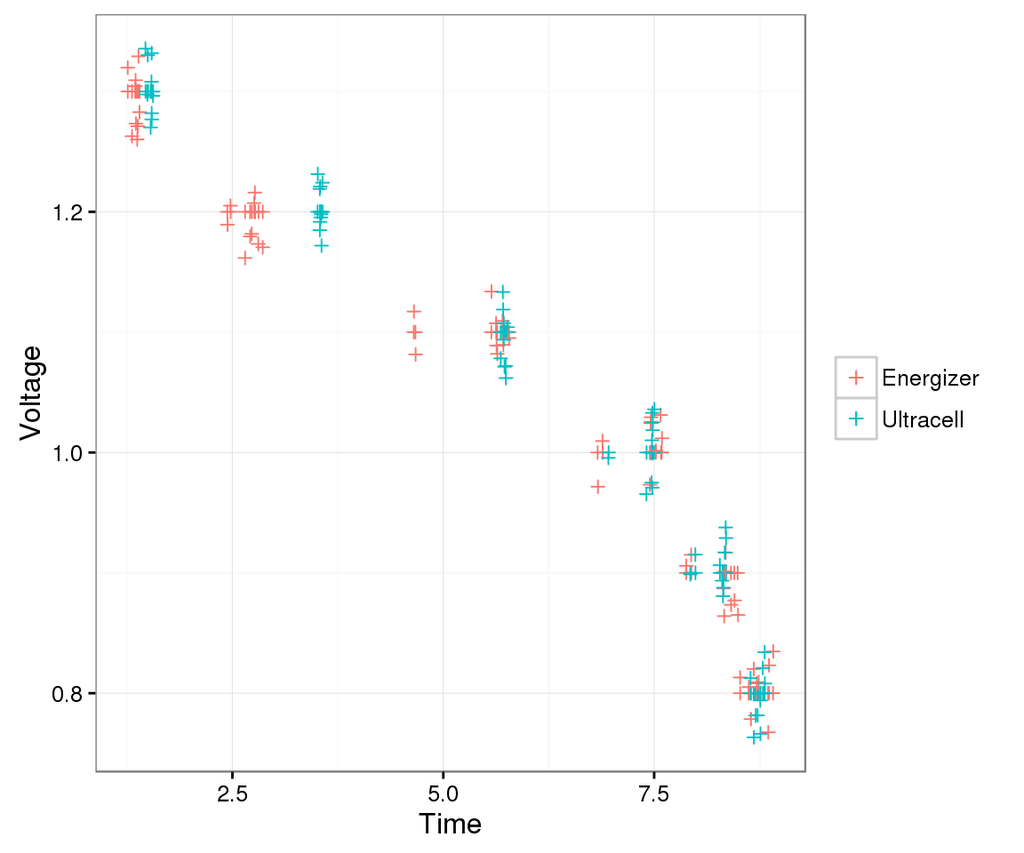

```r
library(ggplot2)

ggplot(batteries2, aes(Time, Voltage, color=factor(Brand)))+
  geom_point(shape=3)+
  geom_jitter(shape=3)+
  theme_bw()+
  theme(legend.title=element_blank())
```

- *What are you first impressions of the relationship between Energizer and Ultracell now that you’ve seen some data?*

# Methods of comparison

The purpose of the original study was to compare the lifetime of two battery brands, but deciding the superior lifetime between the brands is actually more difficult than it initially seems. It’s important to note that a variety of methods could also be used to make this comparison. Some of these methods are illustrated below. Suppose that we are only concerned with the 0.9 volts end-point (though similar issues arise if a different end-point is chosen).

### T-Test

Here we are conducting a t-test to test the hypothesis of no difference between the mean times to decay to 0.9 volts $(H_0: \mu_U = \mu_E)$ against the two-tailed alternative $(H_A: \mu_U ≠ \mu_E)$.

To test the hypothesis of no difference between the mean times to decay to 0.9 volts $(H_0: \mu_U = \mu_E)$ against the two-tailed alternative $(H_A: \mu_U ≠ \mu_E)$, a standard t-test could be used.

- *Run a t-test.*

```r
#Table 4:
# T-test for a difference at 0.9 V
p.t <- t.test(Time ~ Brand,
data=subset(batteries2, Voltage==0.9))
p.t
```

```
    Welch Two Sample t-test

data:  Time by Brand
t = 0.39275, df = 14.825, p-value = 0.7001
alternative hypothesis: true difference in means is not equal to 0
95 percent confidence interval:
 -0.1576026  0.2287137
sample estimates:
mean in group Energizer mean in group Ultracell
               8.278889                8.243333
```

### A bootstrap approach to compare the medians

Here we use the bootstrap approach to compare the medians or means. We are testing: $(H_0: median_U = median_E$ against $H_A: median_U ≠ median_E)$. This code is a little different than code that we’ve previously used, so it is all provided. *Take a look at the documentation for `boot()` to see how the inputs work. Then you may run the code*

```r
# Bootstrap test for a difference at 0.9 V
med.diff <- function(dataset, ind){
 y <- dataset$Time[ind]
 group <- dataset$Brand[ind]
 med.E <- median(y[group=="Energizer"]) # E
 med.U <- median(y[group=="Ultracell"]) # U
 return(med.E - med.U)
}

library(boot) ### LOAD THE boot LIBRARY
out <- boot(subset(batteries2, Voltage==0.9), med.diff, R=5000)
ci.boot <- boot.ci(out)
p.boot <- sum(out$t >= 0)/out$R
p.boot
```

```
[1] 0.899
```

```r
ci.boot
```

```
BOOTSTRAP CONFIDENCE INTERVAL CALCULATIONS
Based on 5000 bootstrap replicates

CALL :
boot.ci(boot.out = out)

Intervals :
Level      Normal              Basic
95%   (-0.1751,  0.1916 )   (-0.1850,  0.2350 )

Level     Percentile            BCa
95%   (-0.1950,  0.2250 )   (-0.3984,  0.1000 )
Calculations and Intervals on Original Scale
```

### A bootstrap approach to compare the means

Dr. Arnholt says that the bootstrap has problems with Quantiles (ie median) and that it’s better to use trimmed mean if you want a robust estimate.

- *Try re-running the bootsrap with the mean instead of the median (You can copy and paste and make necessary adjustments in the code chunk below)*

```r
#time to make new and exciting code!
med.diff <- function(dataset, ind){
 y <- dataset$Time[ind]
 group <- dataset$Brand[ind]
 med.E <- mean(y[group=="Energizer"]) # E
 med.U <- mean(y[group=="Ultracell"]) # U
 return(med.E - med.U)
}

library(boot) ### LOAD THE boot LIBRARY
out <- boot(subset(batteries2, Voltage==0.9), med.diff, R=5000)
ci.boot <- boot.ci(out)
p.boot <- sum(out$t >= 0)/out$R
p.boot
ci.boot
```

[output not shown]

| Method | P-value | Confidence Interval |
| --- | --- | --- |
| t-test | 0.70 | -0.16 to 0.23 |
| Bootstrap (with median) | 0.89 | -0.40 to 0.10 |
| Bootstrap (with mean) | 0.6668 | -0.15 to 0.19 |

- *How to we make sense of these results? Do the tests all agree? Do we reject or fail to reject the null hypothesis?*

ALDI claims that the Ultracell batteries outperform Energizer batteries in two tests (test 1 and 3… the ones that we’re not working with). However, they do not mention the fact that no evidence suggests that Energizer batteries outperform Ultracell batteries in any of the three tests.

- *Is the ALDI claim is accurate or not?*
- *Could the claim could be worded differently for marketing purposes? (for example, “There is no evidence that Energizer batteries last longer on average in any of the three standard tests”).*
- *How would you explain the situation to the person with little statistical knowledge if they had seen the results of table 1?*

### Testing in an overall sense

Note that the times for Energizer and Ultracell can also be compared for **all** the given voltage levels. It may actually end up being more useful to test whether one brand of battery is superior to the other in an overall sense and not just at a specific voltage.

Multiple tests suggest themselves in this scenario as well. The code for an analysis of variance can be completed below.

- *Run an analysis of variance.*

```r
#The repeated measures analyses:
#noting that the experiment is balanced, and treating the voltage levels as factors
t1 <- aov(Time ~ factor(Voltage)*Brand + Error(Battery),
data = batteries2)
summary(t1)
```

```
Error: Battery
          Df Sum Sq Mean Sq F value Pr(>F)
Residuals  1  0.598   0.598

Error: Within
                      Df Sum Sq Mean Sq F value   Pr(>F)
factor(Voltage)        5  782.1  156.42 5216.05  < 2e-16 ***
Brand                  1    1.3    1.35   44.91 1.46e-09 ***
factor(Voltage):Brand  5    2.4    0.49   16.31 1.36e-11 ***
Residuals             95    2.8    0.03
---
Signif. codes:  0 '***' 0.001 '**' 0.01 '*' 0.05 '.' 0.1 ' ' 1
```

```r
model.tables(t1,"means")
```

```
Tables of means
Grand mean

5.753519

 factor(Voltage)
factor(Voltage)
  0.8   0.9     1   1.1   1.2   1.3
8.735 8.261 7.387 5.583 3.117 1.438

 Brand
Brand
Energizer Ultracell
    5.642     5.865

 factor(Voltage):Brand
               Brand
factor(Voltage) Energizer Ultracell
            0.8 8.728     8.742
            0.9 8.279     8.243
            1   7.360     7.414
            1.1 5.442     5.723
            1.2 2.690     3.544
            1.3 1.352     1.523
```

Note: Treating the voltage levels as factors is not necessary, but treating voltage as quantitative needs special attention because the relationship between time and voltage is non-linear.

Brand is brought to our attention in this model (note that brand depends on the voltage level).

- *What are our conclusions from this AOV?*

There is strong evidence suggesting that the Energizer and Ultracell are different in the overall perspective, and that the Ultracell batteries are actually superior!